# Sentiment Analysis

## Sentiment

Used when we want to know the general *feelings* of text.

Applied to Twitter and other social media posts

Can use it anywhere where people have written/said something.

Sentiment can take many different forms: positive/negative affect, emotional states, and even financial contexts.

We will cover two forms of sentiment:

- Word level (simple)
- Sentence level (complex)

## Skipping Around

We are not going to get into text prep now.

It is practically its own lecture.

## Helpful Packages

```r
install.packages(c("tidytext", "sentimentr"))
```

## Simple

Let’s consider the following statements:

```r
library(dplyr); library(tidyr); library(tidytext)

statement <- "I dislike beer, but I really love the shine."

tokens <- tibble(text = statement) %>%
  unnest_tokens(tbl = ., output = word, input = text)

tokens
```

```
## # A tibble: 9 x 1
##   word
##   <chr>
## 1 i
## 2 dislike
## 3 beer
## 4 but
## 5 i
## 6 really
## 7 love
## 8 the
## 9 shine
```

Using our tokens against a pre-defined dictionary:

```r
tokens %>%
  inner_join(get_sentiments("bing")) %>%
  count(sentiment) %>%
  spread(sentiment, n, fill = 0) %>%
  mutate(sentiment = positive - negative)
```

```
## # A tibble: 1 x 3
##   negative positive sentiment
##      <dbl>    <dbl>     <dbl>
## 1        1        2         1
```

## Thinking About The Output

Do you think that disklike and love are of the same magnitude?

I might say that love is stronger than dislike.

Let’s switch out our sentiment library to get something with a little better notion of polarity.

```r
tokens %>%
  inner_join(get_sentiments("afinn"))
```

```
## # A tibble: 2 x 2
##   word    score
##   <chr>   <int>
## 1 dislike    -2
## 2 love        3
```

Now this looks a bit more interesting! “Love” has a stronger positive polarity than “dislike” has negative polarity. So, we could guess that we would have some positive sentiment.

We can get an idea of our sentence’s overall sentiment, if we divide the sum of our word sentiments by the number of words within the dictionary

```r
tokens %>%
  inner_join(get_sentiments("afinn")) %>%
  summarize(n = nrow(.), sentSum = sum(score)) %>%
  mutate(sentiment = sentSum / n)
```

```
## # A tibble: 1 x 3
##       n sentSum sentiment
##   <int>   <int>     <dbl>
## 1     2       1       0.5
```

These simple sentiment analyses provide some decent measures to the sentiment of our text.

We are ignoring big chunks of our text by just counting keywords.

## Smarter Sentiment Analysis

```r
library(sentimentr); library(lexicon); library(magrittr)

statement <- "I dislike beer, but I really love the shine."

sentiment(statement, polarity_dt = lexicon::hash_sentiment_jockers)
```

```
##    element_id sentence_id word_count sentiment
## 1:          1           1          9    0.9375
```

The first part of our sentence starts out negative (dislike has a sentiment value of -1).

We have an adversarial “but” that will downweight whatever is in the initial phrase.

We have the amplified sentiment of “love” (with a weight of .75 in our dictionary).

With all of this together, we get a much better idea about the sentiment of our text.

## An Added Bonus

I want to show you gganimate!

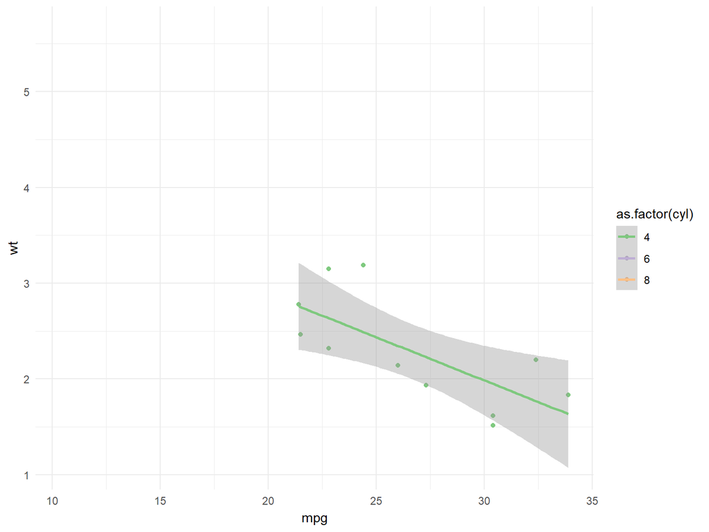

```r
library(gganimate); library(ggplot2)

ggplot(mtcars, aes(mpg, wt, color = as.factor(cyl))) +
  geom_point() +
  geom_smooth(method = "lm") +
  scale_color_brewer(type = "qual") +
  theme_minimal() +
  transition_states(cyl)
```